# Grad Project: Week 10

Brian Detweiler

March 18, 2018

# At a glance

- Established rules and logic for determining $d$-day readmissions ($d$ = 7, 14, 30, 60, 90)
- Built preliminary readmission dataset (will need revision)
- Identified several complexities that will need to be navigated
- Began modeling - very simple logistic regression
- Scheduled final presentation
- When: Friday, May 4th, 1:00-2:00 PM
- Where: University of Nebraska, Omaha - Durham Science Center, room 208,
- Started building presentation for the [Spring MAA NESeSD Section Meeting](http://sections.maa.org/nesesd/)
- Will be partially reusable for final graduate presentation
- When: Friday, April 20th, Time TBD
- Where: University of Nebraska, Omaha - Durham Science Center, room TBD

# Rules rules rules

Establishing rules for building patient profiles has thusfar been the most challenging aspect of this project. Admittedly, this was partly due to a misunderstanding of how readmissions are counted, per the NRD. It turns out, AHRQ provide an [example](https://www.hcup-us.ahrq.gov/db/nation/nrd/NRD_Introduction_2013.jsp) of how analysis should be conducted on the NRD.

The gist of it is, admissions are broken into **index admissions** and **readmission**. An Index Admission is determined by some criteria and is regarded as the first admission we want to track. A readmission is *relative to* the index admission, and is determined by seperate criteria.

Based on the AHRQ paper, and some criteria we are particularly interested in, we have established the following rules to determine an index admission:

We will create five separate datasets based off of the readmission windows we are interested in.

We will consider $d$ day admissions, where $d = \{7, 14, 30, 60, 90\}$.

Why are we starting from month 10 on 2015 rather than 12? Because in 2015, they switched from ICD-9-CM codes to ICD-10-CM codes in October. That would have been ok, except they did not include any CCS codes, [citing](https://www.hcup-us.ahrq.gov/db/nation/nrd/Introduction_NRD_2010-2015.jsp) that the system is still under development. Because of this, we won’t be able to find FMTs.

## Index event rules

```
For years 2010-2014: (1 <= dmonth <= 12 - ceil(d/30))
For 2015: (1 <= dmonth <= 10 - ceil(d/30))
died != 0
los >= 0
age > 0
```

## Readmission event rules

```
The first admission(*) for a patient was within d days of an index event
Subsequent admissions(*) within $d$ days of the index event count as readmission
Discharge may be to the same or a different hospital (HOSP_NRD) and may result in a death
```

(*) NOTE: AHRQ used *discharges* rather than admissions, which I am slightly unclear on. If discharge is counted as (**nrd_timetoevent** + **los**), to me, it seems that does not really measure a *readmission*, and as such, I am only counting **nrd_timetoevent** that falls within the $d$-day window. Although this may just be a technicality of terminiology, as each row in the dataset is called a *discharge*.

## Readmission rates

Percentage of index admissions that had at least one readmission within $d$ days.

```
END_MONTH = 12 for 2010-2014, 10 for 2015
N = total number of index events that had at least one subsequent hospital admission within d days
D = total number of index events between 1 (January) and (END_MONTH - ceil(d/30))
Rate = (N / D) * 100
```

## State diagram

Using these rules, I’ve created a state diagram for building a patient readmission data frame. Keep in mind, the majority of cases will either be a single index event, or an index event and a single readmission. The state diagram logic is to capture the edge cases.

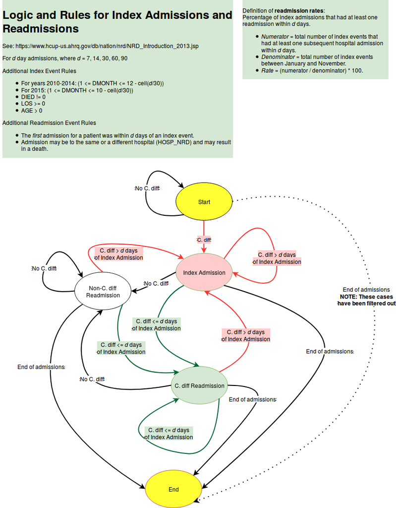

Readmission Rules

# Complications

The NRD contains a list of patients and all of their admissions for the given calendar year. It stores each admission in a separate row. Therefore, performing a quick regressions won’t work.

Most data analysis algorithms rely on the paradigm of *data frames*, in which a single observation resides on a single row. In the NRD, a readmission consists of an index event and one or more readmissions, which will all reside on their own rows. Thus, we need to take these multi-row patient events and collapse them down into a single row that answers the questions we are asking.

To do this, the approach we choose to take is to build a data frame consisting of the index event and the readmissions, and use those to build a **PatientRecord** object. We end up with a list of PatientRecords at the end and we simply convert each to a data frame and bind all of them together to get our final usable data frame.

The code for this is fairly complex (and a little ugly). It is available on my [GitHub](https://github.com/bdetweiler/stat-8960-capstone-project/) for those who are curious.

## Complexities

Complicating things further, up to this point, I had all but ignored the complex survey design of the NRD. Actually, that’s sugar coating it. I didn’t even know what complex survey design was.

In fact, the analyses in prior notebooks, [Week 5](http://bdetweiler.github.io/projects/grad-project/grad-project-1-2018-02-11.html) and [Week 8](http://bdetweiler.github.io/projects/grad-project/grad-project-1-2018-03-04.html) are likely biased due to treating it as an simple random sample. While those analyses were mostly exploratory, in order to publish any of it, stratification, clustering, and weighting will need to be taken into account.

My ignorance has since been remedied. I picked up a copy of [Applied Survey Data Analysis, 2nd Edition](http://www.isr.umich.edu/src/smp/asda/), Heeringa, et. al, and am slowly getting up to speed. Thankfully, has the `survey` package which can be used for performing descriptive statistics and generalized linear models on complex survey data.

## Coding worries

Furthermore, doing a few Google searches for “fecal microbiota” codes result in some rather worrying [forum](https://www.supercoder.com/my-ask-an-expert/topic/new-cpt-code-44705) [discussion](https://engage.ahima.org/communities/community-home/digestviewer/viewthread?GroupId=19&MID=939) [posts](https://www.aapc.com/memberarea/forums/88867-fecal-transplant-eliminate-confusion.html) in which medical professionals seemed unsure of how to code FMTs.

This is the most worrying aspect of the entire project to me. If the data is unreliable, the analysis will be poor. We may be able to mitigate this with some detective work. For example, if these procedures are often reported as a colonoscopy, we may be able to make some inferrences. However, this will require some expert advice.

## Big data! More slowness

Once again, I am running into slow processing issues with this huge dataset. It looks like processing the **PatientRecord** dataset will take about 3 days for each window. I can do this once, but not more. Therefore, I’ve decided that it is will be most important to get my model right. We can model on a small subset of data, and once the model is right, then we can pull in all of it and rerun the model.

# A formative model

Seeing as how I’m already about three weeks behind where I wanted to be at this point, I think it’s time to start with at least a very basic model.

Keeping in mind that this is entirely formative and will look nothing like the final product, I present here, a logistic regression model of readmissions by age, on a small 1000 sample subset of the NRD.

```
##
## Call:
## svyglm(formula = readmitted ~ age.end, design = as.svrepdesign(sample.cdiff),
##     family = quasibinomial, return.replicates = TRUE)
##
## Survey design:
## as.svrepdesign(sample.cdiff)
##
## Coefficients:
##              Estimate Std. Error t value Pr(>|t|)
## (Intercept) -2.216131   0.229707  -9.648  < 2e-16 ***
## age.end      0.016079   0.003183   5.051 5.32e-07 ***
## ---
## Signif. codes:  0 '***' 0.001 '**' 0.01 '*' 0.05 '.' 0.1 ' ' 1
##
## (Dispersion parameter for quasibinomial family taken to be 1.001191)
##
## Number of Fisher Scoring iterations: 4
```

We see that `age.end` has a statistically significant effect on readmission rates (I know, big revelation here). Mostly what this is demonstrating is the use of the `survey::svyglm()` function to produce a logistic regression model while taking stratification, clustering, and weighting into account.

Predicting readmission probabilities for ages 20, 30, 40, …, 90 gives us:

| Age | Prob |
| --- | --- |
| 20 | 0.1307256 |
| 30 | 0.1501057 |
| 40 | 0.1717912 |
| 50 | 0.1958874 |
| 60 | 0.2224557 |
| 70 | 0.2515003 |
| 80 | 0.2829572 |
| 90 | 0.3166839 |

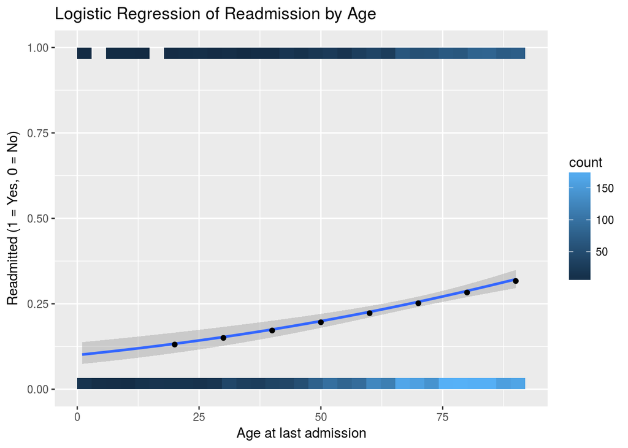

# Next Steps

I will also begin putting together my presentations and final paper, as I expect these to take a significant amount of time.